# Psych 254 W15 PS #1

Robert Hawkins

January 25, 2015

This is problem set #1, in which we hope you will practice the packages tidyr and dplyr. There are some great cheat sheets from [RStudio](http://www.rstudio.com/resources/cheatsheets/).

## The data set

This data set comes from a replication of [Janiszewski and Uy (2008)](http://dx.doi.org/10.1111/j.1467-9280.2008.02057.x), who investigated whether the precision of the anchor for a price influences the amount of adjustment.

In the data frame, the `Input.condition` variable represents the experimental condition (under the rounded anchor, the rounded anchor, over the rounded anchor). `Input.price1`, `Input.price2`, and `Input.price3` are the anchors for the `Answer.dog_cost`, `Answer.plasma_cost`, and `Answer.sushi_cost` items.

## Preliminaries

I pretty much always clear the workspace and load the same basic helper functions before starting an analysis.

```r
rm(list=ls())
setwd("/Users/rxdh/Repos/psych254/analyses/")
source("../helper/useful.R")
```

Note that I’m using a “relative” path (the “../helper”) rather than an absolute path (e.g. “/Users/mcfrank/code/projects/etc…”). The relative path means that someone else can run your code by changing to the right directory, while the absolute path will force someone else to make trivial changes every time they want to run it.

## Part 1: Data cleaning

The first part of this exercise actually just consists of getting the data in a format usable for analysis. This is not trivial. Let’s try it:

```r
d <- read.csv("../data/janiszewski_rep_exercise.csv")
str(d)
```

```
## 'data.frame':    90 obs. of  34 variables:
##  $ HITId                      : Factor w/ 3 levels "261WKUDD8XMBJ8COBQ261TO6T1XNCJ",..: 1 1 1 1 1 1 1 1 1 1 ...
##  $ HITTypeId                  : Factor w/ 1 level "2DVGTP9RA7S5C4ALLOJOM70JMHCRW9": 1 1 1 1 1 1 1 1 1 1 ...
##  $ Title                      : Factor w/ 1 level "How much is it worth? Quick 2 minute survey.": 1 1 1 1 1 1 1 1 1 1 ...
##  $ Description                : Factor w/ 1 level "A quick two minute survey asking about prices. DO THIS HIT ONLY ONCE.": 1 1 1 1 1 1 1 1 1 1 ...
##  $ Keywords                   : Factor w/ 1 level "survey, quick, prices": 1 1 1 1 1 1 1 1 1 1 ...
##  $ Reward                     : num  0.1 0.1 0.1 0.1 0.1 0.1 0.1 0.1 0.1 0.1 ...
##  $ CreationTime               : Factor w/ 1 level "Wed Jan 25 18:13:24 GMT 2012": 1 1 1 1 1 1 1 1 1 1 ...
##  $ MaxAssignments             : int  30 30 30 30 30 30 30 30 30 30 ...
##  $ RequesterAnnotation        : Factor w/ 1 level "Department:Other": 1 1 1 1 1 1 1 1 1 1 ...
##  $ AssignmentDurationInSeconds: int  600 600 600 600 600 600 600 600 600 600 ...
##  $ AutoApprovalDelayInSeconds : int  604800 604800 604800 604800 604800 604800 604800 604800 604800 604800 ...
##  $ Expiration                 : Factor w/ 1 level "Wed Feb 01 18:13:24 GMT 2012": 1 1 1 1 1 1 1 1 1 1 ...
##  $ NumberOfSimilarHITs        : int  2 2 2 2 2 2 2 2 2 2 ...
##  $ LifetimeInSeconds          : logi  NA NA NA NA NA NA ...
```

[output cut: 20 more lines]

Fine, right? Why can’t we go forward with the analysis?

**There are several ways in which the data need to be cleaned. One tip-off about this is that a number of variables that should be numeric end up as factors… In particular, we note:**

1. **Some participants appear multiple times (90 rows, but only 87 worker ids)**
2. **There are commas in some of the input.price numbers**
3. **someone entered their response for “dog cost” as a character string: “five hundred”**

HINT: try computing some summary statistics for the different items. Also, are there any participants that did the task more than once?

Fix the data file so that it looks reasonable.

**To fix these issues, we just open the .csv in another program (e.g. emacs), fix these little problems by hand (or using find/replace), and then save it under a different name, as “cleaned”**

## Part 2: Making these data tidy

Now let’s start with the cleaned data, so that we are all beginning from the same place.

```r
d <- read.csv("../data/janiszewski_rep_cleaned.csv")
```

This data frame is in *wide* format - that means that each row is a participant and there are multiple observations per participant. This data is not *tidy*.

To make this data tidy, we’ll do some cleanup. First, remove the columns you don’t need, using the verb `select`.

HINT: `?select` and the examples of helper functions will help you be efficient.

```r
d.tidy <- select(d, WorkerId, Input.condition,
                 starts_with("Answer"))
```

Try renaming some variables using `rename`. A good naming scheme is:

- consistent with case
- consistent with “.” or “_" ( “_" is usually preferred)
- concise as will be comprehensible to others

Try using the `%>%` operator as well. So you will be “piping” `d %>% rename(...)`.

```r
d.tidy <- d.tidy %>% rename(condition = Input.condition,
                            dog_response = Answer.dog_cost,
                            plasma_response = Answer.plasma_cost,
                            sushi_response = Answer.sushi_cost)
```

OK, now for the tricky part. Use the verb *gather* to turn this into a *tidy* data frame.

HINT: look for online examples!

```r
d.tidy <- d.tidy %>% gather(name, cost,
                 dog_response, plasma_response, sushi_response)
```

Bonus problem: *spread* these data back into a wide format data frame.

```r
d.wide <- d.tidy %>% spread(name, cost)
```

## Part 3: Manipulating the data using dplyr

Try also using the dplyr `distinct` function to remove the duplicate participants from the raw csv file that you discovered in part 1.

```r
d.raw <- read.csv("../data/janiszewski_rep_exercise.csv")
d.unique.subs <- distinct(d.raw, WorkerId)
```

As we said in class, a good thing to do is always to check histograms of the response variable. Do that now, using either regular base graphics or ggplot. What can you conclude?

```
## stat_bin: binwidth defaulted to range/30. Use 'binwidth = x' to adjust this.
```

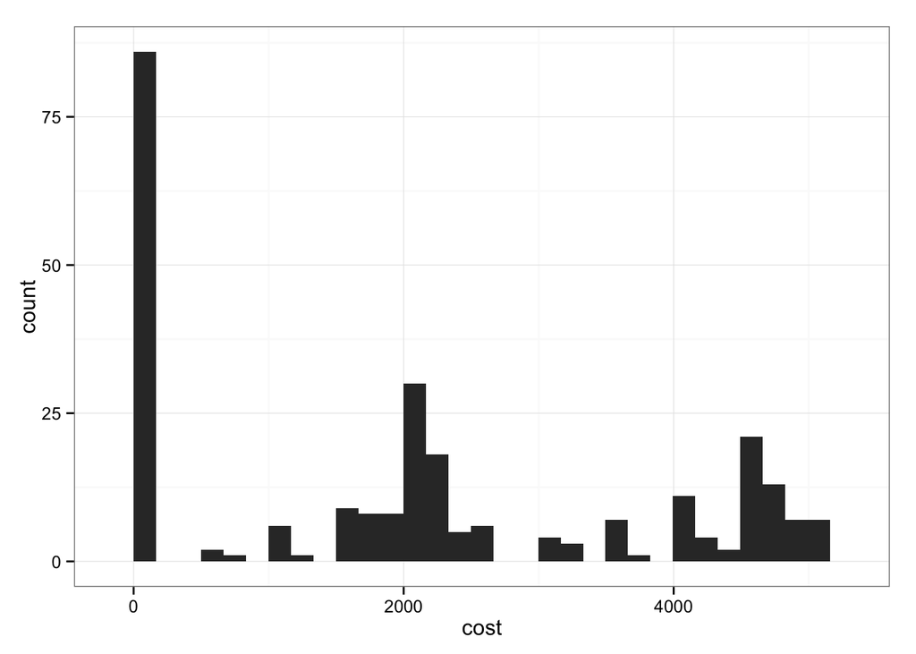

```r
g <- (ggplot(d.tidy, aes(x = cost))
      + geom_histogram())
g
```

**We can conclude that**

1. **there are three clumps of data, corresponding to the three different objects (sushi, dog, plasma)**,
2. **recalling that the anchors were set at 9, 2500, and 5000 (remember, we’re not yet separating out classes of objects), we see that there seems to be a general trend of under-estimation.**

**However, because these three classes of objects are at different scales, it’s hard to compare them all on the same axis… In the following plot, we separate out ‘dog’, ‘plasma’, and ‘sushi’, while still lumping together the ‘over’, ‘under’, and ‘rounded’ anchor conditions. This supports our observation that people tend to be under-estimating prices, overall.**

```
## stat_bin: binwidth defaulted to range/30. Use 'binwidth = x' to adjust this.
## stat_bin: binwidth defaulted to range/30. Use 'binwidth = x' to adjust this.
## stat_bin: binwidth defaulted to range/30. Use 'binwidth = x' to adjust this.
```

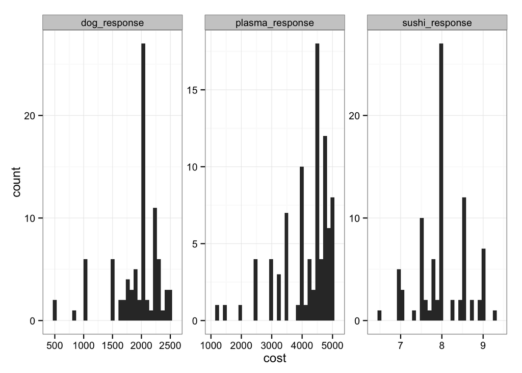

```r
g <- (ggplot(d.tidy, aes(x = cost))
      + geom_histogram()
      + facet_wrap(~ name, scales = 'free'))
g
```

OK, now we turn to the actual data anlysis. We’ll be using dplyr verbs to `filter`, `group`,`mutate`, and `summarise` the data.

Start by using `summarise` on `d.tidy` to compute the mean bet across all participants. Note that this is simply taking the grand mean. Ultimately, we would like to compute the mean for different conditions and items, but this will come later. Right now we’re just learning the syntax of `summarise`.

```r
# Note that worker A3S99S9NJ6X08J left "sushi_response" blank, so we
# must exclude NAs
summarise(d.tidy, m = mean(cost, na.rm = TRUE))
```

```
##          m
## 1 2022.557
```

This is a great time to get comfortable with the `%>%` operator. In brief, `%>%` allows you to pipe data from one function to another. In other words, you get to make a clean list of the things you want to do and chain them together without a lot of intermediate assignments.

Let’s use that capacity to combine `summarise` with `group_by`, which allows us to break up our summary into groups. Try grouping by item and condition and taking means using `summarise`, chaining these two verbs with `%>%`.

```r
d.tidy %>%
  group_by(name, condition) %>%
  summarise(mean_cost = mean(cost, na.rm = TRUE))
```

```
## Source: local data frame [9 x 3]
## Groups: name
##
##              name condition   mean_cost
## 1    dog_response      over 1898.300000
## 2    dog_response   rounded 1884.482414
## 3    dog_response     under 1906.964286
## 4 plasma_response      over 4300.333000
## 5 plasma_response   rounded 4091.655172
## 6 plasma_response     under 4018.357143
## 7  sushi_response      over    8.322414
## 8  sushi_response   rounded    7.955517
## 9  sushi_response     under    7.742500
```

OK, it’s looking like there are maybe some differences between conditions, but how are we going to plot these? They are fundamentally different magnitudes from one another.

Really we need the size of the deviation from the anchor, which means we need the anchor value (the `Input.price` variables that we’ve ignored up until now). Let’s go back to the data and add that in.

Take a look at this complex expression. You don’t have to modify it, but see what is being done here with gather, separate and spread. Run each part (e.g. the first verb, the first two verbs, etc.) and after doing each, look at `head(d.tidy)` to see what they do.

```r
d.tidy <- d %>%
  select(WorkerId, Input.condition,
         starts_with("Answer"),
         starts_with("Input")) %>%
  rename(workerid = WorkerId,
         condition = Input.condition,
         plasma_anchor = Input.price1,
         dog_anchor = Input.price2,
         sushi_anchor = Input.price3,
         dog_cost = Answer.dog_cost,
         plasma_cost = Answer.plasma_cost,
         sushi_cost = Answer.sushi_cost) %>%
  gather(name, cost,
         dog_anchor, plasma_anchor, sushi_anchor,
         dog_cost, plasma_cost, sushi_cost) %>%
  separate(name, c("item", "type"), sep = "_") %>%
  spread(type, cost)
```

Now we can do the same thing as before but look at the relative difference between anchor and estimate. Let’s do this two ways:

- By computing absolute value of percentage change in price, and
- By computing z-scores over items.

To do the first, use the `mutate` verb to add a percent change column, then compute the same summary as before.

```r
pcts <- d.tidy %>%
  mutate(pct_change = abs((anchor - cost) / anchor)) %>%
  group_by(item, condition) %>%
  summarise(pct = mean(pct_change, na.rm = TRUE))
pcts
```

```
## Source: local data frame [9 x 3]
## Groups: item
##
##     item condition       pct
## 1    dog      over 0.2431021
## 2    dog   rounded 0.2462070
## 3    dog     under 0.2347655
## 4 plasma      over 0.1419926
## 5 plasma   rounded 0.1816690
## 6 plasma     under 0.1943951
## 7  sushi      over 0.1108532
## 8  sushi   rounded 0.1160536
## 9  sushi     under 0.1038773
```

To do the second, you will need to `group` first by item, compute z-scores with respect to items, then further group by condition.

HINT: `scale(x)` returns a complicated data structure that doesn’t play nicely with dplyr. try `scale(x)[,1]` to get what you need.

HINT: by default, `group_by` undoes any previous groupings. If you want to add new grouping variables *on top* of pre-existing ones, specify `add = TRUE`, e.g., `d %>% group_by(var1) %>% group_by(var2, add = TRUE)`.

```r
z.scores <- d.tidy %>%
  group_by(item) %>%
  mutate(z_item = scale(cost)[,1]) %>%
  group_by(condition, add = TRUE) %>%
  summarise(z = mean(z_item, na.rm = TRUE))
z.scores
```

```
## Source: local data frame [9 x 3]
## Groups: item
##
##     item condition           z
## 1    dog      over  0.00422195
## 2    dog   rounded -0.02787806
## 3    dog     under  0.02435019
## 4 plasma      over  0.19378470
## 5 plasma   rounded -0.05846743
## 6 plasma     under -0.14707091
## 7  sushi      over  0.53314479
## 8  sushi   rounded -0.09274373
## 9  sushi     under -0.45612967
```

OK, now here comes the end: we’re going to plot the differences and see if anything happened. First the percent change:

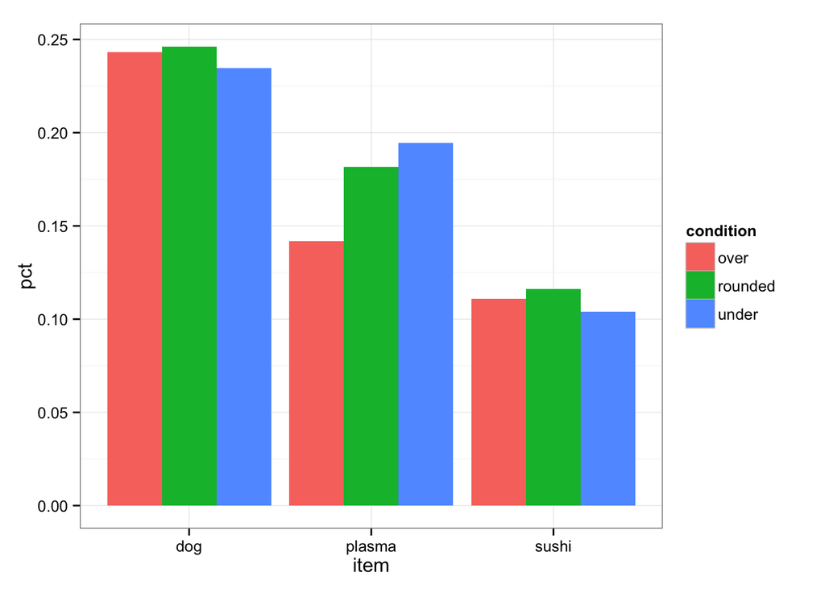

```r
qplot(item, pct, fill=condition,
      position="dodge",
      stat="identity", geom="bar",
      data=pcts)
```

and the z-scores:

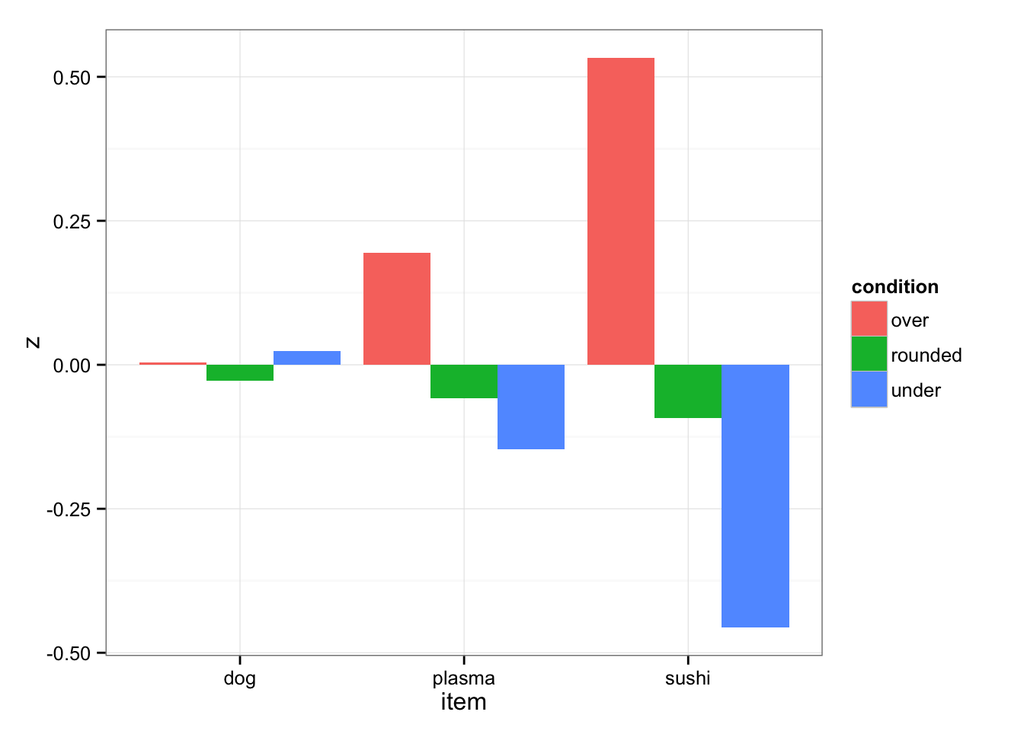

```r
qplot(item, z, fill=condition,
      position="dodge",
      stat="identity", geom="bar",
      data=z.scores)
```

Oh well. This replication didn’t seem to work out straightforwardly.